# Facebook Report

YiLin Liu

March 3, 2017

# Quick Introduction To facebook API:

### Structure:

The facebook Graph API (API used to access general facebook data) is in the form of a *graph*:

| Structure | Description |
| --- | --- |
| nodes | Nodes are like Users, page, groups, comments etc..Each node has its’ own unique ID that which is used to access itself via the Graph API. |
| edges | The connections that leads from one node to another are called edges. For example: the cover photo of a user, the comments and posts on a user’s timeline. Edges are identified by a name |
| fields | Information about the nodes are called fields,like the names, Id, birthdays of a user.Fields are identified by a name. |

### Request Format:

- The *API request* is in the format of a standard HTTP request. Methods like **GET,POST, DELETE, etc.** can be used to retrieve and modify information of facebook nodes through the API granted the correct access token is provided.
- Format of a request:  
  `GET graph.facebook.com /{node-id}/{edge-name}?fields = {first-level fields}{Second-level fields}`.
  - The levels of the fields form a pipeline where the fields of the first level fields can be accessed as the second level fields.
- An OAuth access token is required to access any information, Rfacebook provides functionalities to handle tokens.

### Pagination:

- To manage the amount of information returned per API Call, facebook divides the data using several pagination techniques (Cursors-based, Time-based and Offset-based).
- Most commonly used and the only ones encountered during this report are the curosr based paginations.
- The information for pagination provides a *next* token which is a HTTP GET request for the next page of data and a *previous* token which is a HTTP GET request for the previous page of data.
  - If the provided paging request call returns *NULL*, the end/very beginning of the data is reached.

### Rate Limit:

- The type of rate limit dealt with mainly in this report is **Application-Level Rate Limiting**. Only the application access key was used. [Access Tokens](https://developers.facebook.com/docs/facebook-login/access-tokens)
- The facebook API states that the limit for the application is **200 calls per hour per user in aggregate.** This however means if more users uses the application, the rate limit cap increases.
- However not all API calls are subjected to the rate limit.
- There is a tool that monitors the application’s API calls and it is located under the dashboard of the application. [Test Application](https://developers.facebook.com/apps/). The user would need to be logged in.

# Other Facebook API:

- There is **not** a paid Facebook Graph API.
- For commercial purposes, Facebook has another API called [Marketing API](https://developers.facebook.com/docs/marketing-apis/) which is used to manage ad campaigns.
- Another advertisment based API is the [atlas API](https://developers.facebook.com/docs/atlas-apis). From a basic google search. [This page](https://www.quora.com/What-is-Facebooks-Atlas-exactly) says that the atlas API uses identity of each user to target advertisment.

# Rfacebook Package:

- [Rfacebook](https://cran.r-project.org/web/packages/Rfacebook/index.html)

## Summary of Findings For Rfacebook:

| Advantages | Disadvantages |
| --- | --- |
| Clear documentation. | If an error is thrown by the facebook API, the search stops. |
| High level of Abstraction. | Many functions are no longer supported due to the updated facebook API. |
| Good variety of functions that can provide data from facebook API. | Limited range of fields and edges, does not support the extraction of any arbitrary fields and edges. |
| The source code provides a structure to parse any arbitary facbook API response in JSON. |  |

## List of Deprecated Functions:

| functions | description |
| --- | --- |
| getCheckins | deprecated |
| getFQLS | deprecated |
| getFriends | only your friends who uses your application |
| getNetwork | only applicable to users of your application |
| searchFacebook | deprecated |

## Setting Up Libraries

```r
    ##Loading Libraries needed for the rest of the report:

    library(jsonlite)
    library(knitr)
    library(Rfacebook)
    knitr::opts_chunk$set(error=T,warning=TRUE)

    rm(list = ls())
```

## Creating Test Account:

- *First name:* API-Testing
- *Last name:* nrc
- *Email:* NRC.API.Testing@gmail.com
- *Password:* NRCTesting123456!
- *Birthday:* July 1st 1997
- *Gender:* Males

## Creating token:

- Normally, a temporary access token normally has a 2-hour expiration time. A long-lived token (OAuth token) can be used for longer access. The following outlines how to obtain a long-lived token:
  - __The *fbOAuth* function documentation in [Rfacebook](https://cran.r-project.org/web/packages/Rfacebook/Rfacebook.pdf) outlines the steps.
  - [Mining facebook Data Using R & facebook API!](https://bigdataenthusiast.wordpress.com/2016/03/19/mining-facebook-data-using-r-facebook-API/) also provides steps to creating a long-lived token.

```r
    app_Id = 1353820787971442
    app_Secret = "4841ab73f4f68960ebbf37e5705e2610"

    ## The following shows the code that calls the fbOAuth function
    ## and creates the OAuth token,
    ## it has been commented once executed and the result
    ## is saved in a file
    ## called "my_OAuth.txt" Please run the following code and follow
    ## the instructions printed in the
    ## console in case the file does not exist.

   # token = fbOAuth(app_id = app_Id,app_secret = app_Secret,extended_permissions = TRUE)
   # if(!file.exists("My_OAuth"))
   #  {
   #      file.create("My_OAuth.txt")
   #      save(token, file= "My_OAuth.txt")
   #  }

load("My_OAuth.txt")
   rm(list = setdiff(ls(),c("token","FbObjectId") ))
```

- The following pictures indicates where to navigate to set the extended permissions.

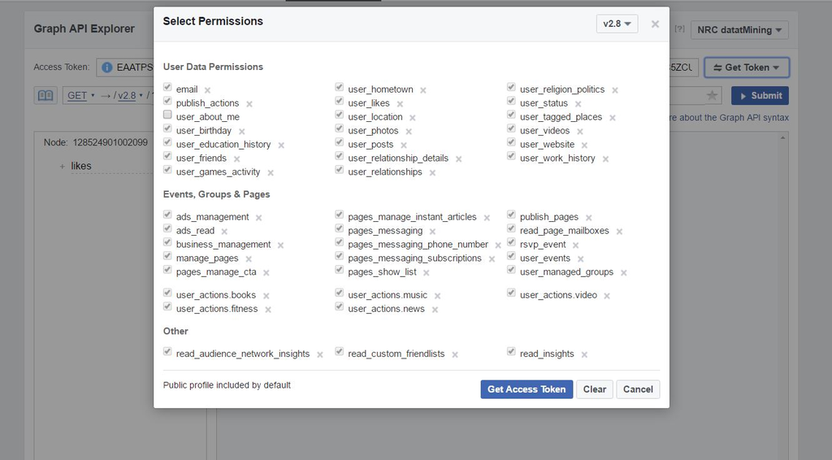

Extended Permissions

# Exploring Rfacebook:

## *Location:*

*GOAL: To try and explore what the facebook API offer regarding extracting location information.*

### Exploring facebook API for Nodes that Contain Location Information:

| Nodes | Description |
| --- | --- |
| Albums. | Contains location field. Often returns null |
| Comments | No location fields. |
| Events | Usually includes location information under the place field with a valid location. |
| Pages | Contains a location field, often yields no useful response. |
| Posts | Contains a place field, but usually returns NULL when requested. |
| Photos | Contains a place field for location. |

## *callAPI* Function:

- The “callAPI” function retrieves response for any valid facebook API requests.
- The main benefit is that the user can pass in any arbitrary API request. ex: `https://graph.facebook.com/me?fields=birthday,age_range` and pass in the token generated from *fbOAuth* token. The users will have to parse the returned nested list.
- Most facebook nodes needs to be referenced via its object id for the expected response.
- Due to personal privacy protection, no useful information about other users (who has not granted access to the test application) were returned.

### Example of using callAPI (to extract test user data):

```r
    load("My_OAuth.txt")
    ##  Extracting test user personnal information
    my_Data = callAPI("https://graph.facebook.com/me", token)
    ##  Extracting my ID, this can be passed on as the ids for other functions
    my_id = my_Data$id
    print(my_Data)
```

```
## $name
## [1] "Api-Testing Nrc"
##
## $id
## [1] "128524901002099"
```

```r
    ##  Adding fields to the URL to gain specific information (birthday, age_range)
    ##  no spaces anywhere within the URL should be included
    my_Specific_Information_Request = "https://graph.facebook.com/me?fields=birthday,age_range"
    my_Specific_Data = callAPI(my_Specific_Information_Request,token)

    print(my_Specific_Data)
```

```
## $birthday
## [1] "07/01/1997"
##
## $age_range
## $age_range$max
## [1] 20
##
## $age_range$min
## [1] 18
##
##
## $id
## [1] "128524901002099"
```

## Exploring *getPage,getPost,getCommentReplies*:

*GOAL: To extract information regarding comments on a public facebook webpage*

```
1:  Starting with getting the post_Ids (mainly post Ids) using _getPage_
```

```r
    require(Rfacebook)

    ##  the getPage function returns a matrix, and one of the
    ##  columns is the "postId"
    BBC_URL = "https://www.facebook.com/bbcnews"
    load("My_OAuth.txt")
    BBC_Id = FbObjectId(BBC_URL,token)
    print(BBC_Id)
```

```
## [1] "228735667216"
```

```r
    ## retrieving page information using
    ## getPage function
    page_Information = getPage(BBC_Id,token,n=2)
```

```
## 2 posts
```

```r
    names(page_Information)
```

```
##  [1] "from_id"        "from_name"      "message"        "created_time"
##  [5] "type"           "link"           "id"             "story"
##  [9] "likes_count"    "comments_count" "shares_count"
```

```r
    ## the post_Ids
    post_Ids = page_Information$id
```

2: Getting information about each post using *getPost* (mainly interested in comment ids)

```r
    ##  trying to see getPost can be vectorized,
    ##  it appears to be working through the use of lapply

    ## getting all the post information with
    ## getPost function
    post_Information = lapply(post_Ids,getPost,n=100,token=token)

    test <- post_Information[[2]]

    names(test)
```

```
## [1] "post"     "likes"    "comments"
```

```r
    names(test$post)
```

```
##  [1] "from_id"        "from_name"      "message"        "created_time"
##  [5] "type"           "link"           "id"             "likes_count"
##  [9] "comments_count" "shares_count"
```

```r
    names(test$likes)
```

```
## [1] "from_name" "from_id"
```

```r
    names(test$comments)
```

```
## [1] "from_id"        "from_name"      "message"        "created_time"
## [5] "likes_count"    "comments_count" "id"
```

3: Using the *getcommentReplies* to further investigate each reply to a comment.

```r
    ## Extracting comment_ids

    comments = unlist( lapply(post_Information, function(x) {x["comments"]}), recursive = F)
    comments_Id = unlist(comments[[1]]["id"])


    #Extracting the comment replies to each posts' comments.

    ## First test the getCommentReplies with a single comment_Id:
    single_Comment_Reply = getCommentReplies(comments_Id[[1]],token=token)
    names(single_Comment_Reply)
```

```
## [1] "comment" "replies"
```

```r
    names(single_Comment_Reply$replies)
```

```
## [1] "from_id"      "from_name"    "message"      "created_time"
## [5] "likes_count"  "id"
```

```r
    ##Now for all of the comment Ids via lapply.

    comment_Replies = lapply(comments_Id, function(x) getCommentReplies(x,token = token))

    length(comment_Replies)
```

```
## [1] 46
```

## Exploring *searchGroup & getGroup* functions:

- *GOAL: To extract information regarding a public facebook group: [couponboutique](https://www.facebook.com/groups/couponboutique2/) using the getGroup function*

1: Suppose the ID is not known, or not certain. *searchGroup()* can be used to extract the group_Id:

```r
    load("My_OAuth.txt")
    group_Name = URLencode("The Coupon Boutique")
    group_Id = searchGroup(group_Name,token=token)
    print(group_Id)
```

```
##                                 name privacy               id
## 1 The Coupon Boutique - Public Group    OPEN 1696255650601823
## 2                The Coupon Boutique  CLOSED 1504395996479976
## 3               The Coupon Boutique2    OPEN 1580411485549988
## 4         Alexis' Couponing Boutique  CLOSED  279585609058254
```

```r
    ##  Also works when URLencoding the search string
    group_Name_URL = URLencode("The Coupon Boutique")
    group_Id2 = searchGroup(group_Name_URL,token=token)
    print(group_Id2)
```

```
##                                 name privacy               id
## 1 The Coupon Boutique - Public Group    OPEN 1696255650601823
## 2                The Coupon Boutique  CLOSED 1504395996479976
## 3               The Coupon Boutique2    OPEN 1580411485549988
## 4         Alexis' Couponing Boutique  CLOSED  279585609058254
```

2: Extracting information using *getGroups*

```r
    start_Time = as.numeric(as.POSIXct("2016-12-01"))
    id = group_Id2$id[[1]]

    ##  This id was manually verfied to be
    ##  the group that is listed at the top
    print(id)
```

```
## [1] "1696255650601823"
```

```r
    ## NOTE: the "groupId" is different from the "pageId"
    ## where the group is posting and hosting.

    #NOTE: the default number of posts to return is 25.
    group_posts = getGroup(id,token=token)
```

```
## 25 posts
```

```r
    class(group_posts)
```

```
## [1] "data.frame"
```

```r
    names(group_posts)
```

```
##  [1] "from_id"        "from_name"      "message"        "created_time"
##  [5] "type"           "link"           "id"             "story"
##  [9] "likes_count"    "comments_count" "shares_count"
```

```r
    rm(list = setdiff(ls(),c("folder_Path","token","FbObjectId") ))
```

## Exploring *searchPage*:

- This method works as shown in the documentation.

```r
    keyword ="Apples"
    data = searchPages(keyword,token, n=100)
```

```
## 100 pages
```

```r
    class(data)
```

```
## [1] "data.frame"
```

```r
   names(data)
```

```
##  [1] "id"                  "about"               "category"
##  [4] "description"         "general_info"        "likes"
##  [7] "link"                "city"                "state"
## [10] "country"             "latitude"            "longitude"
## [13] "name"                "talking_about_count" "username"
## [16] "website"
```

# Search API:

- Allows searches on public information.
- [Search Documentation](https://developers.facebook.com/docs/graph-api/using-graph-api)
- **This API provides the same functionality as facebook’s Search Bar.**
- Query example: `https:graph.facebook.com/search?q={string to search for}&type={type name}&{fields of type}`